# PSTAT131 Final Project

### correlation matrix

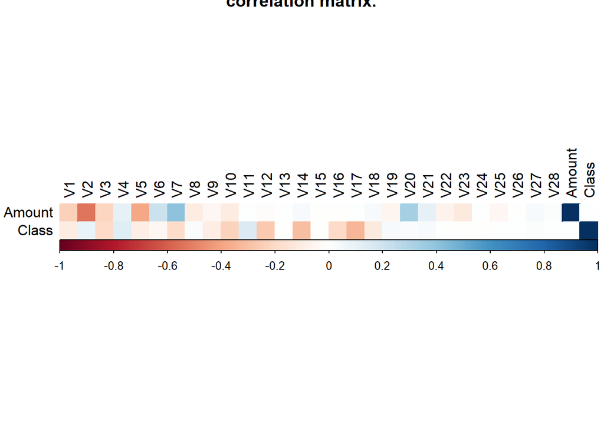

```r
correlations <- cor(df_train[,-1],method="pearson")[c('Amount','Class'),] %>%
corrplot( number.cex = .1, method = "color", type = "full",tl.col = "black",title ='correlation matrix.', cl.pos = "b",cl.ratio = 2.0)
```

## Model Building

### Data prepare

(1)‘Time’ feature does not indicate the actual time of the transaction and is more of listing the data in chronological order.Based on the data visualization above we assume that ‘Time’ feature has little or no significance in correctly classifying a fraud transaction and hence eliminate this column from further analysis.  
(2)Convert the dependent variable to a factor variable and assign a value,while standardizing each independent variable.  
(3)In order to make the training data and test data completely independent and do not affect each other,we preprocess them separately

```r
train <- df_train %>%
  dplyr::select(-Time) %>%
  mutate(Class=factor(Class))
levels(train$Class)<-c("Not_Fraud", "Fraud")
train[,-30] <- scale(train[,-30])

test <- df_test %>%
  dplyr::select(-Time) %>%
  mutate(Class=factor(Class))
levels(test$Class) <- c("Not_Fraud", "Fraud")
test[,-30] <- scale(test[,-30])
```

### Choosing sampling technique

.downsampling

```r
# downsampling
set.seed(123)
down_train <- downSample(x = train[, -ncol(train)],
                         y = train$Class)
down_train %>%
  count(Class)%>%
  mutate(prop = n/sum(n))
```

.upsampling

```r
# upsampling
set.seed(123)
up_train <- upSample(x = train[, -ncol(train)],y = train$Class)
up_train %>%
  count(Class)%>%
  mutate(prop = n/sum(n))
```

.smote

```r
# smote
set.seed(123)
smote_train <- SMOTE(train[, -ncol(train)],train$Class)$data
colnames(smote_train)[30] <- "Class"

smote_train%>%
  count(Class)%>%
  mutate(prop = n/sum(n))
```

We first use the original training data to train the logistic regression model, the test results is: accuracy 99.9%, recall 60%.

```r
recipe <- recipe(Class ~V1+V2+V3+V4+V5+V6+V7+V8+V9+V10+V11+V12+V13+V14+V15+V16+V17+V18+V19+V20
                   +V22+V23+V24+V25+V26+V27+V28+Amount,
                 data = train)
log_model <- logistic_reg() %>%
  set_engine("LiblineaR")%>%
  set_mode("classification")

log_workflow <- workflow() %>%
  add_model(log_model) %>%
  add_recipe(recipe)

#fit the logistic model to the original training set:
set.seed(123)
ori_log_fit <- fit(log_workflow, train)
ori_log_fit %>%
  extract_fit_parsnip() %>%
  tidy()
```

```
## # A tibble: 29 x 2
##    term  estimate
##    <chr>    <dbl>
##  1 V1     -0.178
##  2 V2     -0.159
##  3 V3     -0.0552
##  4 V4     -0.882
##  5 V5     -0.213
##  6 V6      0.169
##  7 V7      0.140
##  8 V8      0.122
##  9 V9      0.179
## 10 V10     0.682
## # ... with 19 more rows
```

```r
#test using original test set
test_pred <- predict(ori_log_fit, new_data = test %>% dplyr::select(-Class))
#metric set
test_res <- bind_cols(test_pred, test%>% dplyr::select(Class))
#head(test_res)
T<-table(test_res)
TP<-T[4]
FN<-T[3]
FP<-T[2]
TN<-T[1]
accuracy=(TP+TN)/sum(T) #0.99921
recall=TP/(TP+FN) #0.61
```

Then We use the down sample data to train the logistic regression model, the test results is: accuracy 97.2%, recall 89%.

```r
#fit the logistic model to the down training set:
set.seed(123)
down_log_fit <- fit(log_workflow, down_train)
#test
down_test_pred <- predict(down_log_fit, new_data = test %>% dplyr::select(-Class))
#metric set
down_test_res <- bind_cols(down_test_pred, test%>% dplyr::select(Class))
down_T<-table(down_test_res)
TP1<-down_T[4]
FN1<-down_T[3]
FP1<-down_T[2]
TN1<-down_T[1]
down_accuracy=(TP1+TN1)/sum(down_T) #0.9721218
down_recall=TP1/(TP1+FN1) #0.89
```

Then We use the up sample data to train the logistic regression model, the test results is: accuracy 97.6%, recall 90%.

```r
set.seed(123)
up_log_fit <- fit(log_workflow, up_train)
#test
up_test_pred <- predict(up_log_fit, new_data = test %>% dplyr::select(-Class))
#metric set
up_test_res <- bind_cols(up_test_pred, test%>% dplyr::select(Class))
up_T<-table(up_test_res)
TP2<-up_T[4]
FN2<-up_T[3]
FP2<-up_T[2]
TN2<-up_T[1]
up_accuracy=(TP2+TN2)/sum(up_T) #0.9759489
up_recall=TP2/(TP2+FN2) #0.9
```

Then We use the smote sample data to train the logistic regression model, the test results is: accuracy 97.6%, recall 91%.

```r
set.seed(123)
smote_log_fit <- fit(log_workflow, smote_train)
#test
smote_test_pred <- predict(smote_log_fit, new_data = test %>% dplyr::select(-Class))
#metric set
smote_test_res <- bind_cols(smote_test_pred, test%>% dplyr::select(Class))
smote_T<-table(smote_test_res)
TP3<-smote_T[3]
FN3<-smote_T[4]
FP3<-smote_T[1]
TN3<-smote_T[2]
smote_accuracy=(TP3+TN3)/sum(smote_T) #0.9764931
smote_recall=TP3/(TP3+FN3) #0.91
```

### Model select using smote data

1.Logistic regression model

2.Boosted Tree Model

3.KNN model

#### Building the Recipe and Tweaking The Data

```r
set.seed(123)
smote_train_folds <- vfold_cv(smote_train, v = 10)
#no repeat to reduce the running time
recipe<-recipe(Class ~ ., data = smote_train)
recipe
```

#### logistic regression model

I tuned penalty, set mode to “classification” (because my outcome is a factor variable), and used the LiblineaR engine. I stored this model and my recipe in a workflow and set up the tuning grid.

```r
log_model <- logistic_reg(penalty = tune(), mixture = 1) %>%
  set_engine("LiblineaR")%>%
  set_mode('classification')

log_workflow <- workflow() %>%
  add_model(log_model) %>%
  add_recipe(recipe)

log_grid <- tibble(penalty = 10^seq(-3, -2, length.out = 20))
```

Then, I executed my model by tuning and fitting. This process took 1 hours and 30 minutes! I wrote out the results and the workflow so I would not need to run it again.

```r
log_res <- log_workflow %>%
  tune_grid(resamples = smote_train_folds,
            grid = log_grid,
            control = control_grid(save_pred = TRUE),
            metrics = metric_set(roc_auc))

#save(log_res, log_workflow, file = "D:/log_res.rda")
```

Taking a quick peak at the autoplot() function and show_best() based on roc_auc metric

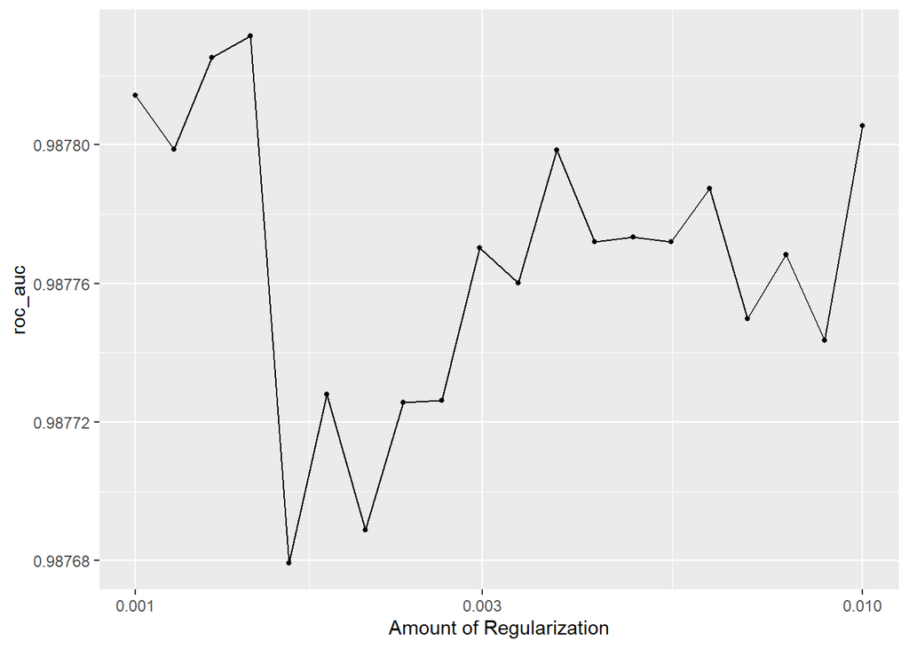

```r
load("D:/log_res.rda")
autoplot(log_res, metric = "roc_auc")  ##0.002-0.003 best
```

```r
show_best(log_res, metric = "roc_auc") %>% dplyr::select(-.estimator, -.config)
```

We’ll create a workflow that has tuned in the name, so we can identify it. We’ll finalize the workflow by taking the parameters from the best model (the logistic regression model) using the select_best() function.

```r
log_workflow_tuned <- log_workflow %>%
  finalize_workflow(select_best(log_res, metric = "roc_auc"))
log_final <- fit(log_workflow_tuned, smote_train)
```

Lets fit the model to the testing data set and use prediction value and true value to create a table for calculating accuracy and recall.The accuracy is 97.6%,recall is 91%

```r
log_test_res <- predict(log_final, new_data = test) %>%
  bind_cols(test %>% dplyr::select(Class))
logT<-table(log_test_res)
TP4<-logT[3]
FN4<-logT[4]
FP4<-logT[1]
TN4<-logT[2]
log_accuracy=(TP4+TN4)/sum(logT) #0.9764053
log_recall=TP4/(TP4+FN4) #0.91
```

#### Boosted Tree Model

Similarly, I set the model with tuning parameters min_n, mtry. I set the engine as xgboost and set mode to “classification”. I created a workflow.

```r
bt_model <- boost_tree(mode = "regression",
                       min_n = tune(),
                       mtry = tune()) %>%
  set_engine("xgboost")%>%
  set_mode('classification')

bt_workflow <- workflow() %>%
  add_model(bt_model) %>%
  add_recipe(recipe)

bt_params <- extract_parameter_set_dials(bt_model) %>%
  update(mtry = mtry(range= c(2, 20)),
         min_n = min_n(range= c(2, 20))
  )

# define grid
bt_grid <- grid_regular(bt_params, levels = 2)
```

Then, I executed my model by tuning and fitting. This process took 5 hours minutes! I wrote out the results and the workflow so I would not need to run it again

```r
bt_res <- bt_workflow %>%
  tune_grid(resamples = smote_train_folds,
            grid = bt_grid,
            control = control_grid(save_pred = TRUE),
            metrics = metric_set(roc_auc))

#save(bt_res, bt_workflow, file = "D:/bt_res.rda")
```

Taking a quick peak at the autoplot() function and show_best() based on roc_auc metric

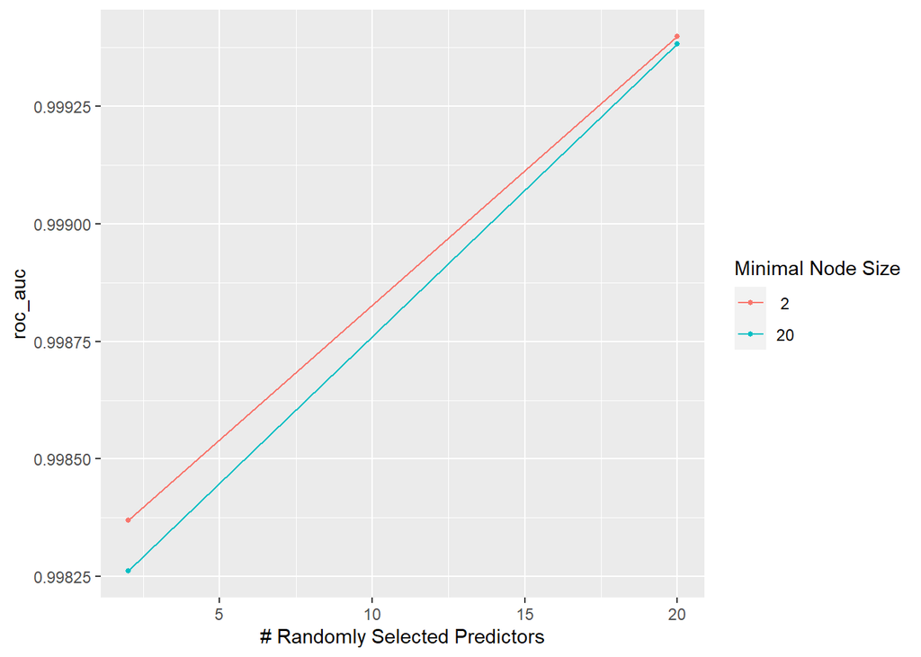

```r
load("D:/bt_res.rda")
autoplot(bt_res, metric = "roc_auc")
```

```r
show_best(bt_res, metric = "roc_auc") %>% dplyr::select(-.estimator, -.config)
```

```r
bt_workflow_tuned <- bt_workflow %>%
  finalize_workflow(select_best(bt_res, metric = "roc_auc"))
bt_final <- fit(bt_workflow_tuned, smote_train)
```

```r
bt_test_res <- predict(bt_final, new_data = test) %>%
  bind_cols(test %>% dplyr::select(Class))
btT<-table(bt_test_res)
TP5<-btT[3]
FN5<-btT[4]
FP5<-btT[1]
TN5<-btT[2]
bt_accuracy=(TP5+TN5)/sum(btT) #0.9915909
bt_recall=TP5/(TP5+FN5) #0.85
```

#### Nearest Neighbors Model

Similarly, I set the model with tuning parameters neighbors. I set the engine as kknn and set mode to “classification”. I created a workflow.

```r
knn_model <- nearest_neighbor(mode = "regression",
                              neighbors = tune()
) %>%
  set_engine("kknn")%>%
  set_mode('classification')

knn_workflow <- workflow() %>%
  add_model(knn_model) %>%
  add_recipe(recipe)

knn_params <- extract_parameter_set_dials(knn_model)

# define grid
knn_grid <- grid_regular(knn_params, levels = 4)
```

Then, I executed my model by tuning and fitting. This process took 3 hours ! I wrote out the results and the workflow so I would not need to run it again

```r
knn_res <- knn_workflow %>%
  tune_grid(resamples = smote_train_folds,
            grid = knn_grid
  )

#save(knn_res, knn_workflow, file = "D:/knn_res.rda")
```

Taking a quick peak at the autoplot() function and show_best() based on roc_auc metric

[figure not shown]

```r
load("D:/knn_res.rda")
autoplot(knn_res, metric = "roc_auc")  ##
```

```r
show_best(knn_res, metric = "roc_auc") %>% dplyr::select(-.estimator, -.config)
```

We’ll create a workflow that has tuned in the name, so we can identify it. We’ll finalize the workflow by taking the parameters from the best model (the knn regression model) using the select_best() function.

```r
knn_workflow_tuned <- knn_workflow %>%
  finalize_workflow(select_best(knn_res, metric = "roc_auc"))
knn_final <- fit(knn_workflow_tuned, smote_train)
```

Lets fit the model to the testing data set and use prediction value and true value to create a table for calculating accuracy and recall.The accuracy is 99.6%,recall is 80%

```r
knn_test_res <- predict(knn_final, new_data = test) %>%
  bind_cols(test %>% dplyr::select(Class))
knnT<-table(knn_test_res)
TP6<-knnT[3]
FN6<-knnT[4]
FP6<-knnT[1]
TN6<-knnT[2]
knn_accuracy=(TP6+TN6)/sum(knnT)
knn_recall=TP6/(TP6+FN6)
```

#### Random Forest Model

Due to the large amount of computation of random forest, training the model with all the training data will run for more than 10 hours, so we randomly sample the training data, and take half of the data to train the model to reduce the training time.  
Similarly, I set the model with tuning parameters mtry I set the engine as ranger and set mode to “classification”. I created a workflow.

```r
index<-sample(c(1:dim(smote_train)[1]),size=round(dim(smote_train)[1]/2))
sampe_smote_train<-smote_train[index,]
sample_smote_train_folds <- vfold_cv(sampe_smote_train, v = 10) #repeat need long time

rf_model <- rand_forest(mode = "regression",
                        min_n = tune(),
                        mtry = tune()) %>%
  set_engine("ranger")%>%
  set_mode('classification')

rf_workflow <- workflow() %>%
  add_model(rf_model) %>%
  add_recipe(recipe)

rf_params <- extract_parameter_set_dials(rf_model) %>%
  update(mtry = mtry(range= c(2, 20))
  )

# define grid
rf_grid <- grid_regular(rf_params, levels = 2)
```

Then, I executed my model by tuning and fitting. This process took 12 hours ! I wrote out the results and the workflow so I would not need to run it again

```r
rf_res <- rf_workflow %>%
  tune_grid(resamples = sample_smote_train_folds,
            grid = rf_grid,
            control = control_grid(save_pred = TRUE),
            metrics = metric_set(roc_auc))

#save(rf_res, rf_workflow, file = "D:/rf_res.rda")
```

Taking a quick peak at the autoplot() function and show_best() based on roc_auc metric

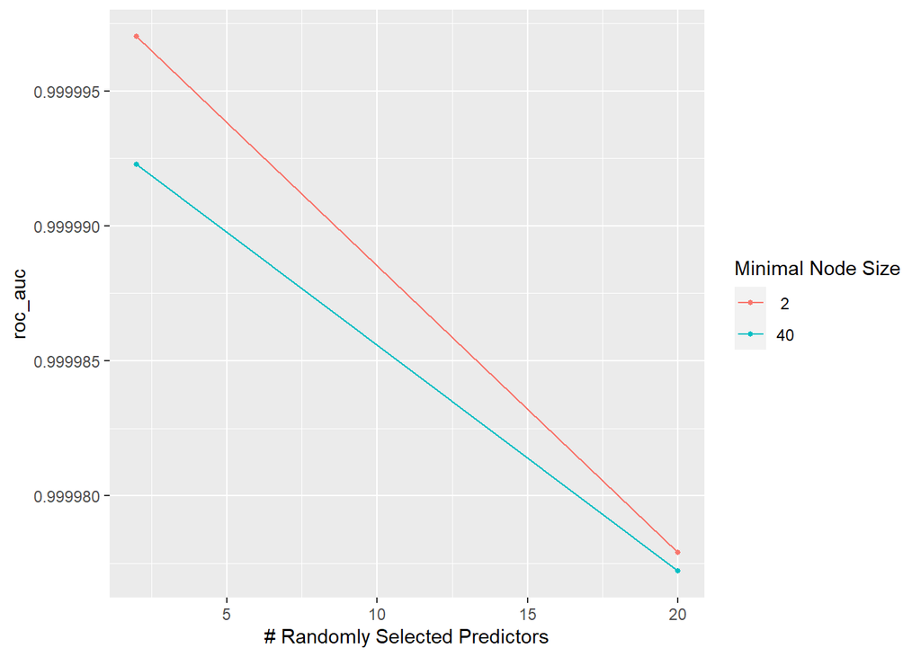

```r
load("D:/rf_res.rda")
autoplot(rf_res, metric = "roc_auc")  ##
```

```r
show_best(rf_res, metric = "roc_auc") %>% dplyr::select(-.estimator, -.config)
```

```r
rf_workflow_tuned <- rf_workflow %>%
  finalize_workflow(select_best(rf_res, metric = "roc_auc"))
rf_final <- fit(rf_workflow_tuned, smote_train)
```

Lets fit the model to the testing data set and use prediction value and true value to create a table for calculating accuracy and recall.The accuracy is 99.9%,recall is 83%

```r
rf_test_res <- predict(rf_final, new_data = test) %>%
  bind_cols(test %>% dplyr::select(Class))
rfT<-table(rf_test_res)
TP7<-rfT[3]
FN7<-rfT[4]
FP7<-rfT[1]
TN7<-rfT[2]
rf_accuracy=(TP7+TN7)/sum(rfT) #
rf_recall=TP7/(TP7+FN7) #
```

## Conclusion

In this project we have tried to show different methods of dealing with unbalanced datasets like the fraud credit card transaction dataset where the instances of fraudulent cases is few compared to the instances of normal transactions. We have argued why accuracy is not a appropriate measure of model performance here and used the metric recall and accuracy to evaluate how different methods of oversampling, undersampling and smotesampling the response variable can lead to better model training. We concluded that the smotesampling technique works best on the dataset based on logistic regression models with not tune. So,we final use smote technique to deal with our training data.  
Finally, we use the balanced data processed by the smote technology to train various machine. models. We selected four commonly machine learning models, namely logistic regression, boosted tree, Nearest Neighbors, and randomforest, and adjusted the parameters of each model. And then used the test data to evaluate the effect of each model. According to the performance of the two indicators of accuracy and recall, we believe that the logistic regression model has the best prediction effect, and its recall rate is the highest, reaching 91%, and its accuracy can also reach 97.6%.